# Raport elektrownie (wersja bez shiny)

Piotr Langa 117330

27 listopada 2017

## Wstęp

Przeprowadzona analiza pomogła znaleźć korelacje pomiędzy poszczególnymi wartościami z czujników a wytwarzaną energią. Wpływ miała tu nie tylko pora dnia i nasłonecznienie, ale również wilgotność, zachmurzenie, siła wiatru, azymut, szerokość i wysokość geograficzna, ciśnienie, punkt rosy i temperatura.

Dostarczone dane nie posiadały opisów oprócz nazw kolumn więc miejscami trudno było określić za co odpowiadają dane atrybuty. Dane w większości były znormalizowane i nie posiadały wartości pustych.

W zbiorze danych występowały wartości zerowe w miejscach gdzie nie powinny się znaleźć - np zerowa wartość atrybutu kwh w środku dnia. W analizie pominięto naprawę błędnych wartości ponieważ było ich niewiele a sama analiza operowała na średnich.

Dane zawierały atrybuty liczbowe jak i nominalne.

## Przygotowanie danych

```r
set.seed(123)
file <- read.csv("elektrownie.csv")
df <- file %>% mutate(date = as.Date(file$data,format="%m/%d/%Y"))
```

## Podsumowanie zbioru danych

| Liczba rekordów | Liczba atrybutów |
| --- | --- |
| 235790 | 51 |

##### Nazwy atrybutów

```
##  [1] "id"                   "idsito"               "idmodel"
##  [4] "idbrand"              "lat"                  "lon"
##  [7] "ageinmonths"          "anno"                 "day"
## [10] "ora"                  "data"                 "temperatura_ambiente"
## [13] "irradiamento"         "pressure"             "windspeed"
## [16] "humidity"             "icon"                 "dewpoint"
## [19] "windbearing"          "cloudcover"           "tempi"
## [22] "irri"                 "pressurei"            "windspeedi"
## [25] "humidityi"            "dewpointi"            "windbearingi"
## [28] "cloudcoveri"          "dist"                 "altitude"
## [31] "azimuth"              "altitudei"            "azimuthi"
## [34] "pcnm1"                "pcnm2"                "pcnm3"
## [37] "pcnm4"                "pcnm5"                "pcnm6"
## [40] "pcnm7"                "pcnm8"                "pcnm9"
## [43] "pcnm10"               "pcnm11"               "pcnm12"
## [46] "pcnm13"               "pcnm14"               "pcnm15"
## [49] "irr_pvgis_mod"        "irri_pvgis_mod"       "kwh"
```

## Rozkład wartości atrybutów

### Atrybuty liczbowe

##### Wartości geograficzne

- lat - szerokość geograficzna
- lon - długość geograficzna
- altitude - wysokość nad poziomem morza
- azimuth - azymut.

##### Wartości metorologiczne

- temperatura_ambiente (część urojona “tempi”) - temperaturę powietrza
- irradiamento (część urojona irri) - nasłonecznienie
- pressure (pressurei) - ciśnienie
- windspeed (windspeedi) - prędkość wiatru
- humidity (humidityi) - wilgotność powietrza
- dewpoint (dewpointi) - punkt rosy
- cloudcover (cloudcoveri) - zachmurzenie

##### Pozostałe wartości

- kwh - kilowatogodziny
- ageinmonths - wiek czujnika w miesiącach

##### Nieopisane wartości

Częśc wartości okazała się niemożliwa do odgadnięcia z podanej nazwy

- dist - jest to albo jakaś odległość fizyczna albo odległość na macierzy pomyłek
- irr_pvgis_mod (irri_pvgis_mod)

### Atrybuty nominalne

##### Opis wartości

- id - identyfikator pomiaru
- idsito - id czujnika
- idmodel - id modelu czujnika
- idbrand - id marki
- data - data i czas pomiaru
- pcnm1… pcnm15 - wartości głównych współrzędnych macierzy sąsiedztwa
- icon - ikona, prawdopodobnie jakieś oznaczenie techniczne

## Korelacja pomiędzy zmiennymi

### Średni kwh od godziny i zachmurzenia z podziałem na rok

Atrybut kwh został uśredniony dla danej godziny (ora) z okresu całego roku i zachmurzenia (cloudcover)

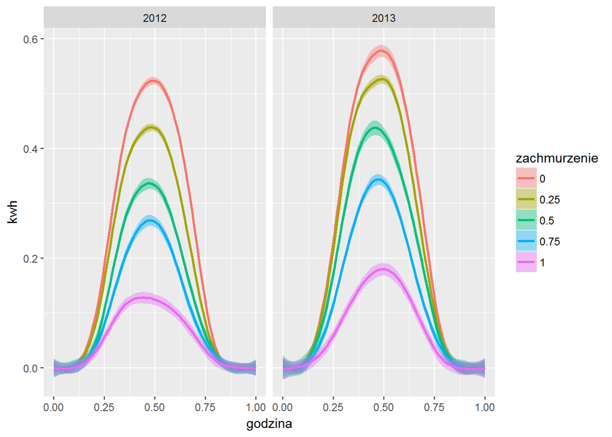

### Średni kwh i średnie nasłonecznienie od godziny z podziałem na rok

Atrybuty kwh i irradimento zostały uśrednione dla danej godziny (ora) z okresu całego roku

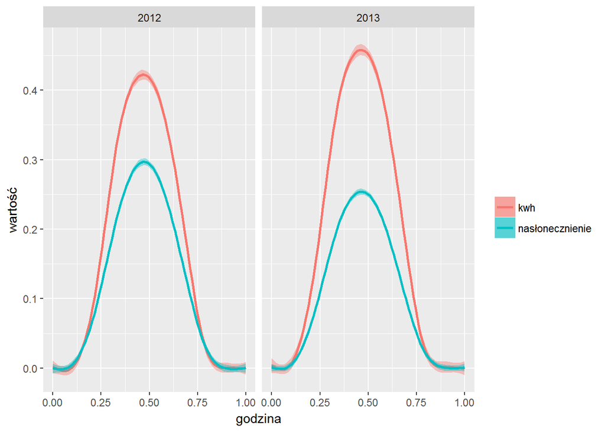

### Średni kwh od nasłonecznienia i wilgotności

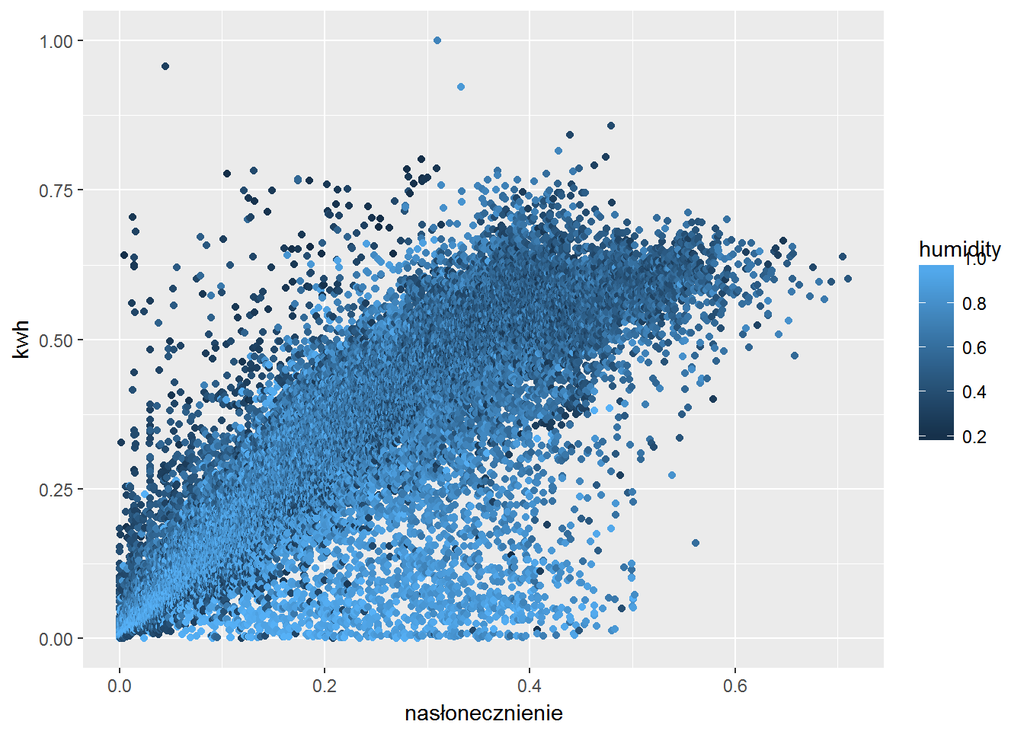

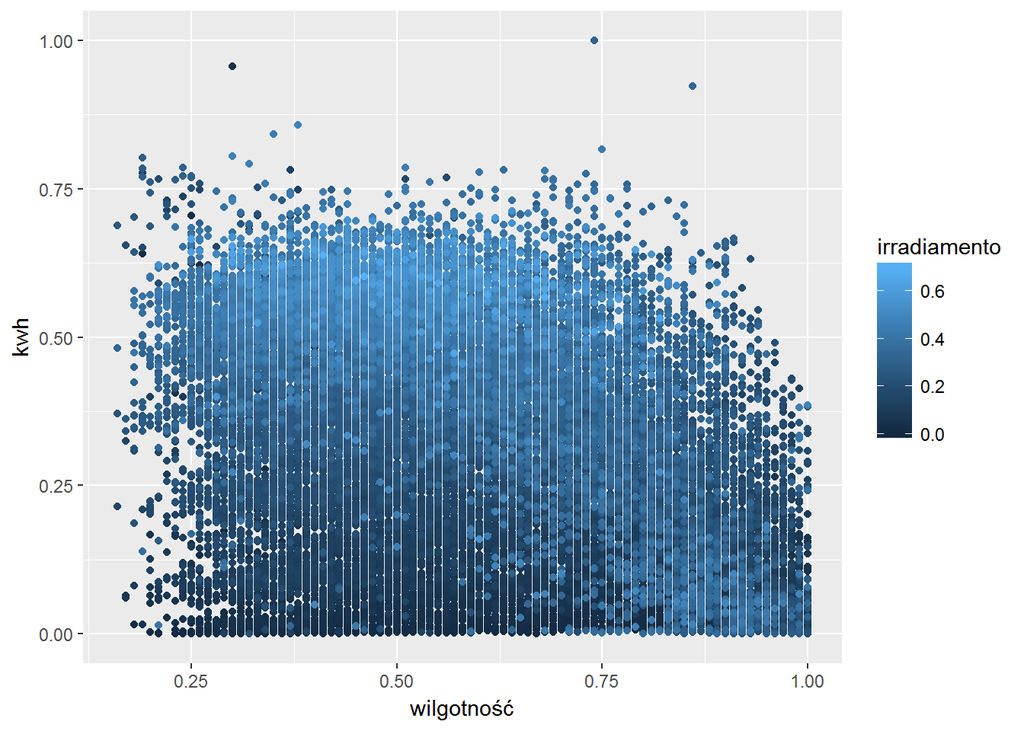

### Średni kwh i średnie nasłonecznienie od miesiąca

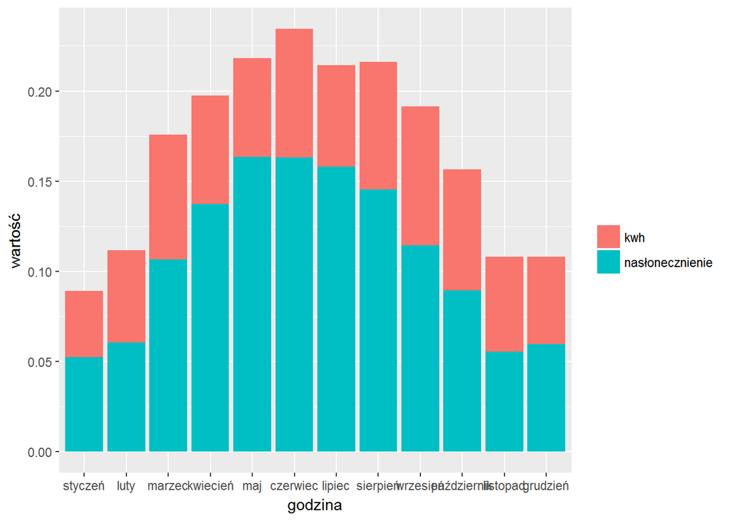

Z wykresu wynika, że najwyższa wartość kwh jest latem i osiąga maksimum w czerwcu. Ponownie można zauważyć korelację kwh i nasłonecznienia.

## Regresja

W celu zbadania wpływu atrybutów na jakość przewidzenia wytwarzanej energii w ujęciu godzinowym zbudowano kilka modelów regresji i zbadano ich jakość na podstawie miary RMSE

|  | atrybuty | RMSE |
| --- | --- | --- |
| RMSE | lat, lon, ageinmonths, anno, day, ora, temperatura_ambiente, irradiamento, pressure, windspeed, humidity, dewpoint, windbearing, cloudcover, altitude, azimuth, kwh | 0.1024694 |
| RMSE1 | ora, irradiamento, kwh | 0.1069518 |
| RMSE2 | anno, day, ora, temperatura_ambiente, irradiamento, pressure, windspeed, humidity, dewpoint, windbearing, cloudcover, altitude, azimuth, kwh | 0.1025660 |
| RMSE3 | anno, day, ora, temperatura_ambiente, irradiamento, pressure, windspeed, dewpoint, cloudcover, kwh | 0.1045008 |

Najlepszym modelem regresji okazał się pierwszy testowany model z atrybutami lat, lon, ageinmonths, anno, day, ora, temperatura_ambiente, irradiamento, pressure, windspeed, humidity, dewpoint, windbearing, cloudcover, altitude, azimuth i kwh.

### Analiza ważności atrybutów dla najlepszego modelu regresji

|  | atrybuty | RMSE |
| --- | --- | --- |
| RMSE | lat, ora, kwh | 0.2097959 |
| RMSE1 | lon, ora, kwh | 0.2097960 |
| RMSE2 | ageinmonths, ora, kwh | 0.2097474 |
| RMSE3 | anno, ora, kwh | 0.2097120 |
| RMSE4 | day, ora, kwh | 0.2098154 |
| RMSE5 | temperatura_ambiente, ora, kwh | 0.1968280 |
| RMSE6 | irradiamento, ora, kwh | 0.1069518 |
| RMSE7 | pressure, ora, kwh | 0.2092939 |
| RMSE8 | windspeed, ora, kwh | 0.2084309 |
| RMSE9 | humidity, ora, kwh | 0.1741260 |
| RMSE10 | dewpoint, ora, kwh | 0.2085917 |
| RMSE11 | windbearing, ora, kwh | 0.2078441 |
| RMSE12 | cloudcover, ora, kwh | 0.2083899 |
| RMSE13 | altitude, ora, kwh | 0.1656673 |
| RMSE14 | azimuth, ora, kwh | 0.1936659 |

Jak można było przewidzieć, najistotniejszy wpływ na jakość predykcji ma atrybut irradiamento, czyli nasłonecznienie.